# Homework 2 Report

## Name

Saharsh Manderwad

### Setup

Read in the data with `read_csv()` and store the data as an R object named `dataset`. Check the data to make sure all of the expected observations and variables are there.

```r
## Load the data and any necessary packages here.
knitr::opts_chunk$set(
  echo = TRUE, message = FALSE, warning = FALSE,
  fig.align = "center", fig.width = 7, fig.height = 5,
  out.width = "90%", dpi = 144
)
need <- c("readr","dplyr")
to_install <- setdiff(need, rownames(installed.packages()))
if (length(to_install)) install.packages(to_install, quiet = TRUE)
suppressPackageStartupMessages(
  invisible(lapply(need, function(pkg) library(pkg, character.only = TRUE)))
)

fname <- if (file.exists("maacs.csv")) "maacs.csv" else if (file.exists("maacs.csv.gz")) "maacs.csv.gz" else stop("maacs.csv[.gz] not found.")
dataset <- readr::read_csv(fname, show_col_types = FALSE)

tibble::tibble(rows = nrow(dataset), cols = ncol(dataset)) |>
  knitr::kable(caption = "Dataset dimensions")
```

Dataset dimensions

| rows | cols |
| --- | --- |
| 150 | 10 |

```r
tibble::tibble(variable = names(dataset)) |>
  knitr::kable(caption = "Variable names")
```

Variable names

| variable |
| --- |
| id |
| age |
| gender |
| fev1 |
| eNO |
| cough_days |
| pm25 |
| no2 |
| mouse |
| mouse_allergic |

```r
expected_cols <- c("id","age","gender","fev1","eNO","cough_days","pm25","no2","mouse","mouse_allergic")
tibble::tibble(expected = expected_cols, present = expected_cols %in% names(dataset)) |>
  knitr::kable()
```

| expected | present |
| --- | --- |
| id | TRUE |
| age | TRUE |
| gender | TRUE |
| fev1 | TRUE |
| eNO | TRUE |
| cough_days | TRUE |
| pm25 | TRUE |
| no2 | TRUE |
| mouse | TRUE |
| mouse_allergic | TRUE |

```r
dup_ids <- sum(duplicated(dataset$id))
tibble::tibble(duplicate_ids = dup_ids) |>
  knitr::kable(caption = "Duplicate ID count")
```

Duplicate ID count

| duplicate_ids |
| --- |
| 0 |

```r
missing <- sapply(dataset, function(x) sum(is.na(x)))
tibble::tibble(variable = names(missing), n_missing = as.integer(missing)) |>
  dplyr::arrange(dplyr::desc(n_missing)) |>
  knitr::kable()
```

| variable | n_missing |
| --- | --- |
| no2 | 47 |
| mouse | 34 |
| pm25 | 20 |
| fev1 | 17 |
| eNO | 17 |
| id | 0 |
| age | 0 |
| gender | 0 |
| cough_days | 0 |
| mouse_allergic | 0 |

## Part 1

We will first consider the relationship between FEV1 and age. In general, it is expected that as children get older (and hence, larger in size), their FEV1 values should get higher.

Consider the statement “FEV1 values in children are higher in older children relative to younger children”.

Write a function in R that takes the `dataset` object as an argument and returns `TRUE` if the statement above is true for the dataset and `FALSE` otherwise.

NOTE: In order to write this function, you will need to translate the statement above into something that can be checked with the data. There are many ways in which you can do that translation correctly and you only need to pick one way here.

NOTE: For this part, do not use any plots.

```r
## Write your function here
fev1_age_statement_true <- function(dataset) {
  d <- dataset[, c("fev1","age")]
  d <- d[complete.cases(d), ]
  if (nrow(d) < 3) return(FALSE)
  fit <- lm(fev1 ~ age, data = d)
  co <- summary(fit)$coefficients
  as.logical(co["age","Estimate"] > 0 & co["age","Pr(>|t|)"] < 0.05)
}

tibble::tibble(statement_true = fev1_age_statement_true(dataset)) |>
  knitr::kable(caption = "Part 1 result")
```

Part 1 result

| statement_true |
| --- |
| TRUE |

## Part 2

Fit a linear regression model with FEV1 as the outcome and age as a predictor.

How much does FEV1 change for a 1-year increase in the child’s age?

```r
## Add your code here
fit_age <- lm(fev1 ~ age, data = dataset)
coef_age <- unname(coef(fit_age)["age"])
ci_age <- confint(fit_age, "age", level = 0.95)
p_age <- summary(fit_age)$coefficients["age","Pr(>|t|)"]

knitr::kable(
  data.frame(
    term = "age (per 1 year)",
    estimate = round(coef_age, 3),
    conf.low = round(ci_age[1], 3),
    conf.high = round(ci_age[2], 3),
    p = format.pval(p_age, digits = 3)
  ),
  caption = "Linear regression: FEV1 ~ age (effect of age)"
)
```

Linear regression: FEV1 ~ age (effect of age)

| term | estimate | conf.low | conf.high | p |
| --- | --- | --- | --- | --- |
| age (per 1 year) | 0.171 | 0.149 | 0.193 | <2e-16 |

```r
sm <- summary(fit_age)
knitr::kable(
  data.frame(
    R2 = round(sm$r.squared, 3),
    Adj_R2 = round(sm$adj.r.squared, 3),
    N = stats::nobs(fit_age)
  ),
  caption = "Model fit (minimal)"
)
```

Model fit (minimal)

| R2 | Adj_R2 | N |
| --- | --- | --- |
| 0.65 | 0.647 | 133 |

Write your data analysis statement interpreting the regression model here:

FEV1 changes by about 0.171 L for every additional year of age (95% CI: 0.149 to 0.193).

## Part 3

Develop **three** supporting premises derived from the data that support the statement you wrote in Part 2. These can be plots, other summary statistics, or model results.

NOTE:

- At least one supporting premise should use a plot.
- Do not use the code you write in Part 1 as a supporting premise

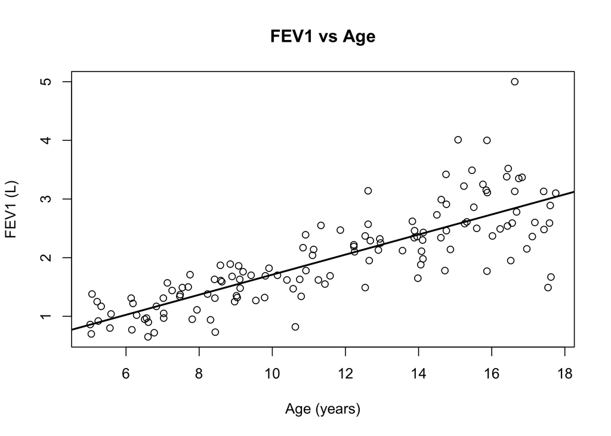

```r
## Add your code here
d <- dataset[, c("age","fev1")]
d <- d[complete.cases(d), ]

ct <- cor.test(d$age, d$fev1)
cor_r <- unname(ct$estimate)
cor_p <- ct$p.value
p_txt <- format(cor_p, scientific = TRUE, digits = 3)

q1_thresh <- as.numeric(quantile(d$age, 0.25, na.rm = TRUE))
q3_thresh <- as.numeric(quantile(d$age, 0.75, na.rm = TRUE))
mean_young <- mean(d$fev1[d$age <= q1_thresh], na.rm = TRUE)
mean_old   <- mean(d$fev1[d$age >= q3_thresh], na.rm = TRUE)
diff_q4_q1 <- mean_old - mean_young

fit_p3 <- lm(fev1 ~ age, data = d)
slope_p3 <- unname(coef(fit_p3)["age"])
ci_p3 <- confint(fit_p3, "age", level = 0.95)

plot(d$age, d$fev1, xlab = "Age (years)", ylab = "FEV1 (L)", main = "FEV1 vs Age")
abline(fit_p3, lwd = 2)
```

Write the three supporting premise statements here:

1. A Pearson correlation test shows a positive association between age and FEV1 (r = 0.806, p = 1.27e-31).
2. Children in the highest age quartile (≥ Q3) have a greater mean FEV1 than those in the lowest quartile (≤ Q1), with a difference of 1.724 L (2.867 vs. 1.143 L).
3. The regression line fitted to the scatterplot indicates a positive slope of 0.171 L per year (95% CI: 0.149–0.193).

## Part 4

For each of the supporting premises above, write a function that takes the `dataset` object as an argument and returns `TRUE` if the supporting premise statement above is true for the dataset and `FALSE` otherwise.

For statements involving plots, instead of returning `TRUE` or `FALSE`, you function should do two things:

1. Produce the plot that is used in the statement
2. Produce a hypothetical version of the plot in the event that the statement is true. This can be done using simulated data or by simply hand drawing a plot.

```r
## Function for supporting premise statement 1
premise1_positive_correlation <- function(dataset) {
  d <- dataset[, c("age","fev1")]
  d <- d[complete.cases(d), ]
  if (nrow(d) < 3) return(FALSE)
  ct <- suppressWarnings(cor.test(d$age, d$fev1))
  isTRUE(unname(ct$estimate) > 0 & ct$p.value < 0.05)
}
tibble::tibble(
  Premise = "Correlation > 0 & significant",
  Result  = premise1_positive_correlation(dataset)
) |>
  knitr::kable(caption = "Premise 1 check")
```

Premise 1 check

| Premise | Result |
| --- | --- |
| Correlation > 0 & significant | TRUE |

```r
## Function for supporting premise statement 2
premise2_q4_greater_than_q1 <- function(dataset) {
  d <- dataset[, c("age","fev1")]
  d <- d[complete.cases(d), ]
  if (nrow(d) < 3) return(FALSE)
  q1 <- as.numeric(quantile(d$age, 0.25, na.rm = TRUE))
  q3 <- as.numeric(quantile(d$age, 0.75, na.rm = TRUE))
  m_young <- mean(d$fev1[d$age <= q1], na.rm = TRUE)
  m_old   <- mean(d$fev1[d$age >= q3], na.rm = TRUE)
  isTRUE(m_old > m_young)
}
tibble::tibble(
  Premise = "Oldest quartile mean > youngest",
  Result  = premise2_q4_greater_than_q1(dataset)
) |>
  knitr::kable(caption = "Premise 2 check")
```

Premise 2 check

| Premise | Result |
| --- | --- |
| Oldest quartile mean > youngest | TRUE |

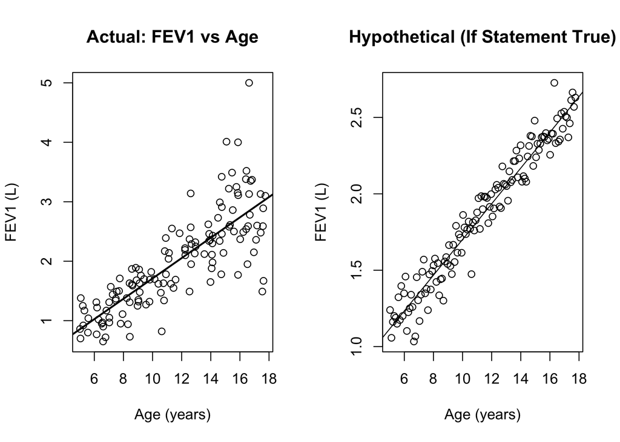

```r
## Function for supporting premise statement 3
premise3_plots <- function(dataset) {
  d <- dataset[, c("age","fev1")]
  d <- d[complete.cases(d), ]
  if (nrow(d) < 3) {
    plot.new(); title("Insufficient data for plot"); return(invisible(NULL))
  }
  old_par <- par(no.readonly = TRUE); on.exit(par(old_par))
  par(mfrow = c(1,2))

  plot(d$age, d$fev1, xlab = "Age (years)", ylab = "FEV1 (L)", main = "Actual: FEV1 vs Age")
  fit <- lm(fev1 ~ age, data = d)
  abline(fit, lwd = 2)

  set.seed(42)
  ages <- seq(min(d$age), max(d$age), length.out = max(100, nrow(d)))
  fev  <- 0.5 + 0.12*ages + rnorm(length(ages), 0, 0.1)
  plot(ages, fev, xlab = "Age (years)", ylab = "FEV1 (L)", main = "Hypothetical (If Statement True)")
  abline(lm(fev ~ ages))
  invisible(NULL)
}
premise3_plots(dataset)
```

Execute each of your function and show that the produce the expected output.

## Part 5

Describe one alternative to the primary statement “FEV1 values in children are higher in older children relative to younger children”.

Create a fault tree for the alternative outcome describing how the alternative outcome could be realized in the data even if the primary statement were true.

Your fault tree should be created as a separate image and does not need to be created in R. Upload the image of the fault tree to Canvas.